# Exploratory Data Analysis

By Parsian Asgari

## Table of Content

1. Data Profiling
2. Multi-Variate Analysis

## Data Profiling

At first we are going to profile the data table.

### Import libraries

```python
import os.path
import sys
module_path = os.path.abspath(os.path.join('..'))
if module_path not in sys.path:
    sys.path.append(module_path)
```

```python
%matplotlib inline

import numpy as np
import pandas as pd
import re

from matplotlib import pyplot as plt
from src.my_data_tools.csv_stitcher import *
from src.my_data_tools.data_profiler import *
```

```python
def correlation_matrix(df, lbl_font_size=10):
    f = plt.figure(figsize=(25, 22))
    plt.matshow(df.corr(), fignum=f.number)
    plt.xticks(range(df.shape[1]), df.columns, fontsize=lbl_font_size, rotation=60)
    plt.yticks(range(df.shape[1]), df.columns, fontsize=lbl_font_size)
    cb = plt.colorbar()
    cb.ax.tick_params(labelsize=14, bottom=True, top=True, labelbottom=True, labeltop=True)
```

### Set path to data folder

```python
parentdir = os.path.dirname(os.getcwd())
datadir = os.path.join(parentdir,'data','raw')
dataprocessed = os.path.join(parentdir,'data','processed')
```

### Profile Data Tables

We are going to stiched the .csv files into one dataframe:

```python
stitcher = CSV_Stitcher(datadir, dataprocessed)
```

```python
stitched_df = stitcher.stitch_csv()
```

```
The following .csv files will get stitched:
['1_record_diast.csv', '2_record_diast.csv', '3_record_diast.csv', '4_record_diast.csv', '5_record_diast.csv', '6_record_diast.csv', '7_record_diast.csv', '8_record_diast.csv', '9_record_diast.csv', '10_record_diast.csv', '11_record_diast.csv', '12_record_diast.csv', '13_record_diast.csv', '14_recor…
Stitching is done!
```

```
Beginning of summary for stitched_dataframe:


Data columns of stitched_dataframe:


<class 'pandas.core.frame.DataFrame'>
Int64Index: 636984 entries, 0 to 46417
Data columns (total 67 columns):
Unnamed: 0    636984 non-null int64
target        636984 non-null float64
feature_1     636984 non-null float64
feature_2     636984 non-null float64
feature_3     636984 non-null float64
feature_4     636984 non-null float64
feature_5     636984 non-null float64
feature_6     636984 non-null int64
feature_7     636984 non-null int64
feature_8     636984 non-null float64
feature_9     636984 non-null float64
feature_10    567418 non-null float64
feature_11    636984 non-null float64
feature_12    636984 non-null float64
feature_13    636984 non-null float64
feature_14    636984 non-null float64
feature_15    636984 non-null float64
feature_16    636984 non-null float64
feature_17    636984 non-null float64
feature_18    636984 non-null float64
feature_19    636984 non-null int64
feature_20    636984 non-null int64
feature_21    636984 non-null float64
feature_22    636984 non-null float64
feature_23    602417 non-null float64
feature_24    636984 non-null float64
feature_25    636984 non-null float64
feature_26    636984 non-null float64
feature_27    636984 non-null float64
feature_28    636984 non-null float64
feature_29    636984 non-null float64
```

[output cut: 23 more lines]

```
feature_53    636984 non-null float64
feature_54    636984 non-null float64
feature_55    636984 non-null float64
feature_56    636984 non-null float64
feature_57    636984 non-null float64
feature_58    636984 non-null float64
feature_59    636984 non-null float64
feature_60    636984 non-null float64
feature_61    636984 non-null float64
feature_62    567418 non-null float64
feature_63    636984 non-null float64
feature_64    636984 non-null float64
feature_65    636984 non-null float64
dtypes: float64(60), int64(7)
memory usage: 330.5 MB
```

```
None
```

```
Your selected dataframe has 67 columns and 636984 Rows.
There are 6 columns that have missing values.
```

|  | Zero Values | Missing Values | % of Total Values | Total Zero Missing Values | % Total Zero Missing Values | Data Type |
| --- | --- | --- | --- | --- | --- | --- |
| feature_10 | 0 | 69566 | 10.9 | 69566 | 10.9 | float64 |
| feature_62 | 0 | 69566 | 10.9 | 69566 | 10.9 | float64 |
| feature_36 | 0 | 37907 | 6.0 | 37907 | 6.0 | float64 |
| feature_23 | 0 | 34567 | 5.4 | 34567 | 5.4 | float64 |
| feature_49 | 0 | 34567 | 5.4 | 34567 | 5.4 | float64 |
| feature_50 | 0 | 6743 | 1.1 | 6743 | 1.1 | float64 |

```
None


Missing data in following columns of stitched_dataframe:
['feature_10', 'feature_23', 'feature_36', 'feature_49', 'feature_50', 'feature_62']




Summary statistics of stitched_dataframe:
```

|  | Unnamed: 0 | target | feature_1 | feature_2 | feature_3 | feature_4 | feature_5 | feature_6 | feature_7 | feature_8 | ... | feature_56 | feature_57 | feature_58 | feature_59 | feature_60 | feature_61 | feature_62 | feature_63 | feature_64 | feature_65 |
| --- | --- | --- | --- | --- | --- | --- | --- | --- | --- | --- | --- | --- | --- | --- | --- | --- | --- | --- | --- | --- | --- |
| count | 636984.000000 | 636984.000000 | 636984.000000 | 636984.000000 | 636984.000000 | 636984.000000 | 636984.000000 | 636984.000000 | 636984.000000 | 636984.000000 | ... | 636984.000000 | 636984.000000 | 636984.000000 | 636984.000000 | 636984.000000 | 636984.000000 | 5.674180e+05 | 636984.000000 | 636984.000000 | 636984.000000 |
| mean | 23136.179587 | 0.824384 | -0.002268 | 2.578558 | -0.004813 | 4.740789 | 0.355492 | -9.092688 | 7.356752 | 0.115058 | ... | 0.039721 | 0.000139 | 0.067050 | 0.170892 | 0.010526 | -0.360798 | -1.132135e+05 | 0.009533 | 0.000011 | 0.000023 |
| std | 15102.776195 | 13.514631 | 0.114981 | 58.633681 | 0.881745 | 50.996810 | 315.486952 | 208.745729 | 100.606405 | 10.802240 | ... | 0.731420 | 4.005408 | 2.904532 | 1.411209 | 0.158086 | 7.565213 | 4.093004e+06 | 0.808356 | 0.001329 | 0.000713 |
| min | 0.000000 | -38.789069 | -0.442888 | -326.830173 | -4.329042 | -250.188024 | -15101.976619 | -1267.000000 | -466.000000 | -51.438373 | ... | -3.394542 | -204.097315 | -15.953482 | -6.953532 | -0.860979 | -35.365325 | -1.910679e+08 | -3.535837 | -0.007890 | -0.003432 |
| 25% | 10616.000000 | -10.448009 | -0.079603 | -33.160539 | -0.542595 | -26.996671 | -2.310731 | -129.000000 | -48.000000 | -7.757576 | ... | -0.408112 | -0.032152 | -1.757263 | -0.694000 | -0.104254 | -4.885868 | -1.655958e+03 | -0.546141 | -0.000764 | -0.000329 |
| 50% | 21232.000000 | 0.738244 | -0.002208 | 1.132718 | -0.005212 | 3.352715 | -0.121381 | -17.000000 | 7.000000 | 0.000000 | ... | 0.048565 | -0.001766 | -0.256996 | 0.109384 | 0.000000 | 0.315379 | 4.150574e+01 | 0.005875 | 0.000015 | 0.000000 |
| 75% | 33953.000000 | 11.816608 | 0.072853 | 36.766553 | 0.532174 | 35.856974 | 1.992675 | 111.000000 | 62.000000 | 8.108597 | ... | 0.506594 | 0.030223 | 1.750437 | 0.933788 | 0.124055 | 4.555765 | 1.710066e+03 | 0.565295 | 0.000821 | 0.000425 |
| max | 63888.000000 | 41.215521 | 0.441461 | 401.968822 | 4.344163 | 261.884958 | 15155.830162 | 1139.000000 | 498.000000 | 56.888889 | ... | 4.433059 | 213.291725 | 18.366384 | 8.440754 | 1.011087 | 32.153368 | 1.665337e+07 | 3.835928 | 0.007100 | 0.003091 |

8 rows × 67 columns

```
First 5 rows of stitched_dataframe:
```

|  | Unnamed: 0 | target | feature_1 | feature_2 | feature_3 | feature_4 | feature_5 | feature_6 | feature_7 | feature_8 | ... | feature_56 | feature_57 | feature_58 | feature_59 | feature_60 | feature_61 | feature_62 | feature_63 | feature_64 | feature_65 |
| --- | --- | --- | --- | --- | --- | --- | --- | --- | --- | --- | --- | --- | --- | --- | --- | --- | --- | --- | --- | --- | --- |
| 0 | 0 | -0.613031 | -0.053620 | -31.607668 | -0.157781 | 18.810949 | 46.398207 | -33 | -14 | -5.329104 | ... | 0.254669 | 0.628154 | -0.446765 | -0.189537 | -0.072147 | 0.624837 | -350.621060 | 0.925521 | 0.000201 | 0.000106 |
| 1 | 1 | 2.912298 | -0.101502 | -51.074790 | 0.299416 | -21.747255 | 47.560793 | -17 | 11 | -5.329104 | ... | -0.294421 | 0.643893 | -0.230152 | 0.148922 | -0.072147 | 0.062113 | -295.188462 | 0.802615 | -0.000074 | -0.000264 |
| 2 | 2 | 6.129125 | -0.094319 | -81.653791 | 0.102004 | -29.935130 | 45.707137 | -16 | -77 | -3.881140 | ... | -0.405271 | 0.618798 | -0.216613 | -1.042451 | -0.052544 | 0.732674 | 146.479143 | 1.145548 | -0.000089 | 0.000053 |
| 3 | 3 | 2.928182 | -0.112184 | -64.922236 | 0.288529 | -26.148199 | 46.367224 | -27 | 3 | -5.329104 | ... | -0.354003 | 0.627734 | -0.365535 | 0.040615 | -0.072147 | 0.409759 | -637.510898 | 0.277151 | 0.001875 | 0.000687 |
| 4 | 4 | 0.154080 | -0.025889 | -23.782382 | 0.043226 | -10.377502 | 54.084277 | -126 | -40 | -1.599500 | ... | -0.140494 | 0.732210 | -1.705829 | -0.541533 | -0.021655 | 3.256243 | -2415.396347 | 0.179903 | 0.000981 | 0.000687 |

5 rows × 67 columns

```
Frequency of missing data across the table indices
```

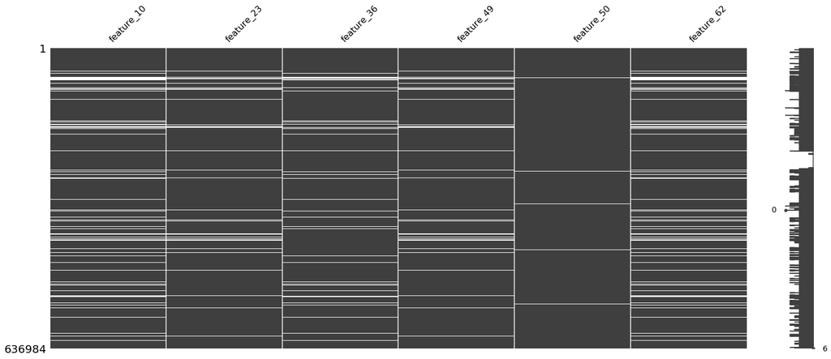

```python
profiler = Data_Profiler(stitched_df)
profiled_data = profiler.profile_data('stitched_dataframe')
missing_value_cols = profiled_data
```

### Profiling Summary:

| Columns | Zero Values | Missing Values | % of Total Values | Total Zero Missing Values | % Total Zero Missing Values | Data Type |
| --- | --- | --- | --- | --- | --- | --- |
| feature_10 | 0 | 69566 | 10.9 | 69566 | 10.9 | float64 |
| feature_62 | 0 | 69566 | 10.9 | 69566 | 10.9 | float64 |
| feature_36 | 0 | 37907 | 6.0 | 37907 | 6.0 | float64 |
| feature_23 | 0 | 34567 | 5.4 | 34567 | 5.4 | float64 |
| feature_49 | 0 | 34567 | 5.4 | 34567 | 5.4 | float64 |
| feature_50 | 0 | 6743 | 1.1 | 6743 | 1.1 | float64 |

```python
stitched_df[missing_value_cols].head()
```

|  | feature_10 | feature_23 | feature_36 | feature_49 | feature_50 | feature_62 |
| --- | --- | --- | --- | --- | --- | --- |
| 0 | -25898.409963 | -70588.733545 | -96487.143508 | 11.164626 | 2.582906 | -350.621060 |
| 1 | -21803.915059 | -70588.733545 | -92392.648604 | 11.164626 | 2.582906 | -295.188462 |
| 2 | 10819.592247 | -70588.733545 | -59769.141298 | 11.164626 | 2.582906 | 146.479143 |
| 3 | -47089.352278 | -70588.733545 | -117678.085823 | 11.164626 | 2.582906 | -637.510898 |
| 4 | -178411.772828 | -70588.733545 | -249000.506373 | 11.164626 | 2.582906 | -2415.396347 |

As the volume of the missing data is greater than 1%, dropping these rows are not a viable option. In order to get a better insight, let's look at some statistics:

```python
stitched_df = stitched_df.drop(['Unnamed: 0'], axis=1)
analysis_df = stitched_df.copy()
```

```python
analysis_df[missing_value_cols].describe()
```

|  | feature_10 | feature_23 | feature_36 | feature_49 | feature_50 | feature_62 |
| --- | --- | --- | --- | --- | --- | --- |
| count | 5.674180e+05 | 6.024170e+05 | 5.990770e+05 | 602417.000000 | 630241.000000 | 5.674180e+05 |
| mean | -9.153134e+06 | -1.170495e+06 | -9.948113e+06 | 12.119569 | 3.464664 | -1.132135e+05 |
| std | 3.296234e+08 | 2.372170e+07 | 3.226835e+08 | 1.034875 | 1.487879 | 4.093004e+06 |
| min | -1.204409e+10 | -8.996316e+08 | -1.204412e+10 | 9.938926 | -14.569337 | -1.910679e+08 |
| 25% | -1.170999e+05 | -2.906731e+05 | -2.981701e+05 | 11.477121 | 2.908090 | -1.655958e+03 |
| 50% | 2.912593e+03 | -1.641073e+05 | -1.652772e+05 | 12.008276 | 3.985152 | 4.150574e+01 |
| 75% | 1.164288e+05 | -9.648286e+04 | -9.426336e+04 | 12.579955 | 4.493417 | 1.710066e+03 |
| max | 8.994912e+08 | -2.072149e+04 | -2.072149e+04 | 20.617496 | 5.260510 | 1.665337e+07 |

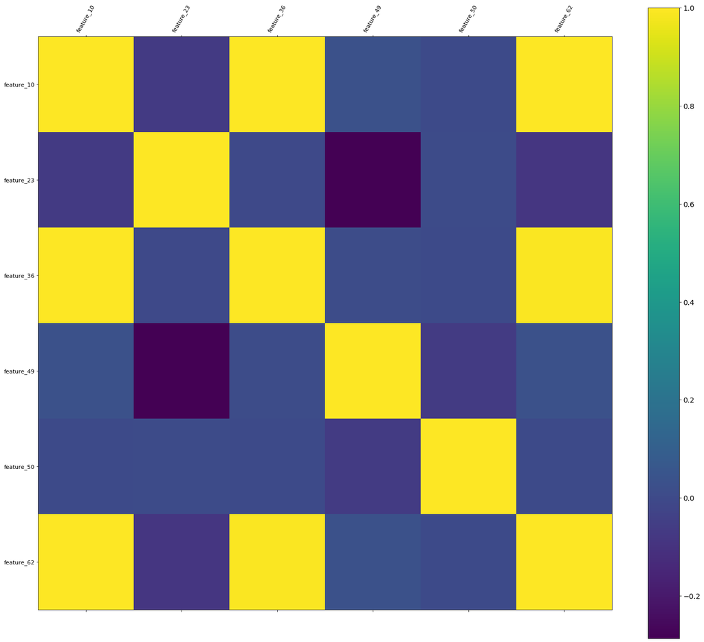

```python
missing_val_corr = correlation_matrix(analysis_df[missing_value_cols], lbl_font_size=11)
missing_val_corr
```

## Multi-Variate Analysis

Since the summary statistics are already covered in the profiling phase, we are going to jump into the multivariate analysis. In this section, since we are looking at continuous data for both the target the feature columns, we are going to use a Pearson's correlation matrix to visualize the association strengths:

Pearson's Correlation test:

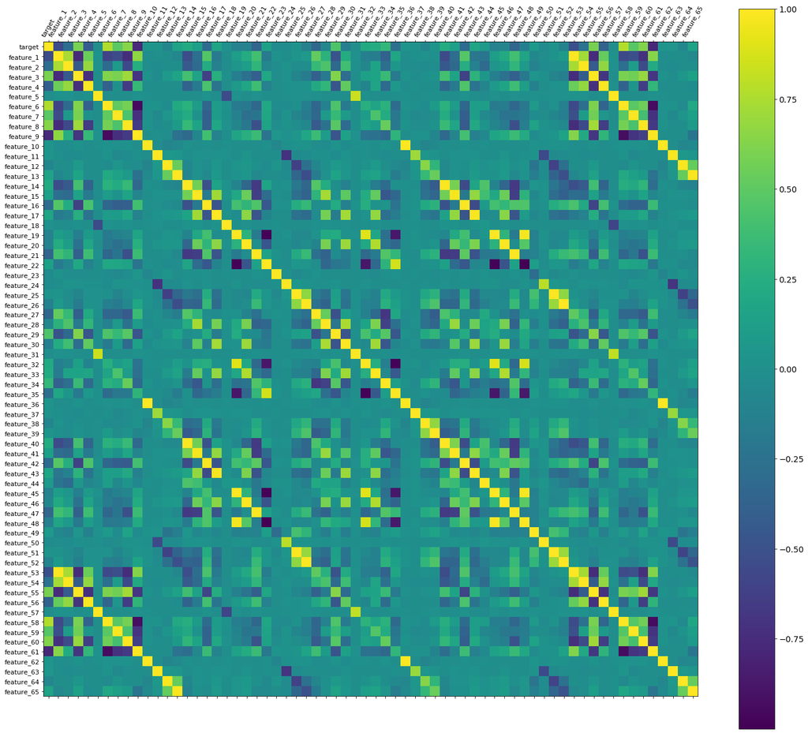

```python
full_analysis_df = correlation_matrix(analysis_df, lbl_font_size=11)
full_analysis_df
```

Here is an overview of highly correlated columns:

```python
highly_corr = analysis_df.corr().abs()
unstacked_highly_corr = highly_corr.unstack()
unstacked_highly_corr_sorted = unstacked_highly_corr.sort_values(kind='quicksort', ascending=False).drop_duplicates()
unstacked_highly_corr_sorted[unstacked_highly_corr_sorted > 0.75]
```

```
feature_65  feature_65    1.000000
feature_48  feature_22    0.999944
feature_19  feature_45    0.999938
feature_10  feature_36    0.997592
feature_47  feature_21    0.997480
feature_26  feature_52    0.996653
feature_62  feature_10    0.996595
feature_36  feature_62    0.993399
feature_57  feature_5     0.992432
feature_58  feature_6     0.988823
feature_9   feature_61    0.988774
feature_25  feature_51    0.988380
feature_60  feature_8     0.988285
feature_4   feature_56    0.987662
feature_16  feature_42    0.987417
feature_59  feature_7     0.986795
feature_3   feature_55    0.986727
feature_46  feature_20    0.986677
feature_11  feature_63    0.986361
feature_2   feature_54    0.986343
feature_1   feature_53    0.986181
feature_40  feature_14    0.984824
feature_64  feature_12    0.984367
feature_43  feature_17    0.984283
feature_13  feature_65    0.983047
feature_22  feature_45    0.977545
feature_48  feature_45    0.977067
feature_32  feature_35    0.976997
feature_22  feature_19    0.976862
feature_48  feature_19    0.976271
feature_41  feature_15    0.973620
feature_9   feature_6     0.940117
feature_58  feature_61    0.934205
feature_6   feature_61    0.930348
feature_58  feature_9     0.923262
feature_32  feature_45    0.906446
            feature_19    0.905535
feature_45  feature_35    0.871807
feature_35  feature_19    0.870138
feature_48  feature_32    0.869182
feature_22  feature_32    0.868631
feature_48  feature_35    0.862700
feature_22  feature_35    0.861466
feature_31  feature_5     0.841983
feature_57  feature_31    0.805502
feature_50  feature_24    0.795173
feature_58  target        0.769747
feature_61  target        0.769449
target      feature_9     0.764709
feature_6   target        0.764233
feature_33  feature_46    0.762650
feature_3   feature_1     0.761811
feature_20  feature_33    0.758403
dtype: float64
```

Correlation of Target with features (Absolute value of the R > 0.5):

```python
target_feature_corr = analysis_df.corr().abs()
target_feature_corr = target_feature_corr.iloc[0,:].sort_values(kind='quicksort', ascending=False)
target_feature_corr[target_feature_corr > 0.5]
```

```
target        1.000000
feature_58    0.769747
feature_61    0.769449
feature_9     0.764709
feature_6     0.764233
feature_8     0.639927
feature_60    0.619816
feature_3     0.601055
feature_55    0.589409
feature_1     0.542631
feature_53    0.513072
Name: target, dtype: float64
```

Let us look at Pearson's correlation matrix for these sets of features:

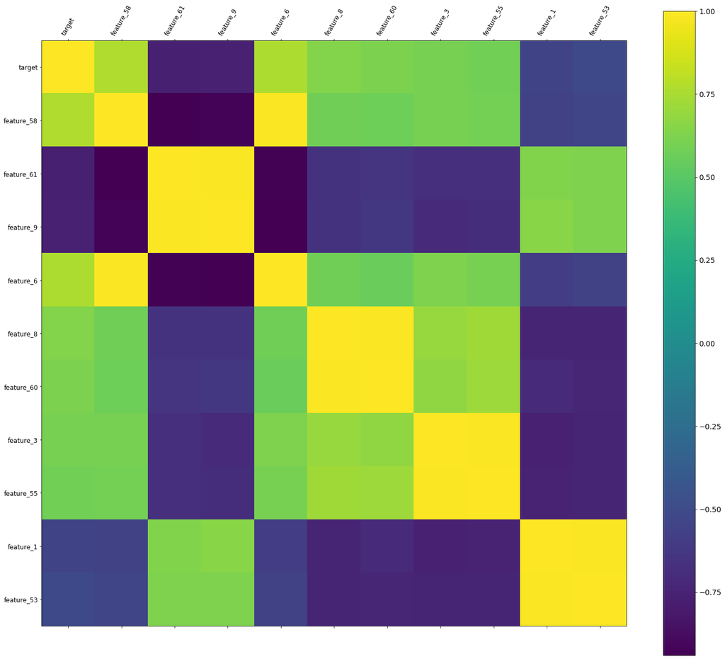

```python
sub_cols = ['target',
            'feature_58',
            'feature_61',
            'feature_9',
            'feature_6',
            'feature_8',
            'feature_60',
            'feature_3',
            'feature_55',
            'feature_1',
            'feature_53']
sub_analysis_df = correlation_matrix(analysis_df[sub_cols], lbl_font_size=12)
```